# Lecture #13: The Bivariate and Multivariate Normal Distributions

MATH 321 – Mathematical Statistics I

Torin Quinlivan

tquinlivan@knox.edu

Knox College

November 10, 2025

## Normal Distribution

We’ve now dealt with the single variable Normal distribution a lot.

$$\begin{gather*}
X \sim \text{Normal}(\mu, \sigma^2) \\
f_X(x) = \frac{1}{\sqrt{2 \pi \sigma^2}} \exp\left\{ -\frac{(x - \mu)^2}{2\sigma^2} \right\}
\end{gather*}$$

How might we generalize this to several variables?

## The Bivariate Normal Distribution

We could use independence.

Suppose that:
$$\begin{aligned}
X &\sim \text{Normal}(\mu_1, \sigma_1^2) \\
Y &\sim \text{Normal}(\mu_2, \sigma_2^2) \\
\end{aligned}$$

If $X$ and $Y$ are independent, then:
$$f_{XY}(x, y) = \frac{1}{2 \pi \sigma_1 \sigma_2} \exp\left\{ -\frac{1}{2} \left[ \left( \frac{x - \mu_1}{\sigma_1} \right)^2 + \left( \frac{x - \mu_2}{\sigma_2} \right)^2 \right] \right\}$$

## The Bivariate Normal Distribution

[interactive chart not shown]

## The Bivariate Normal Distribution

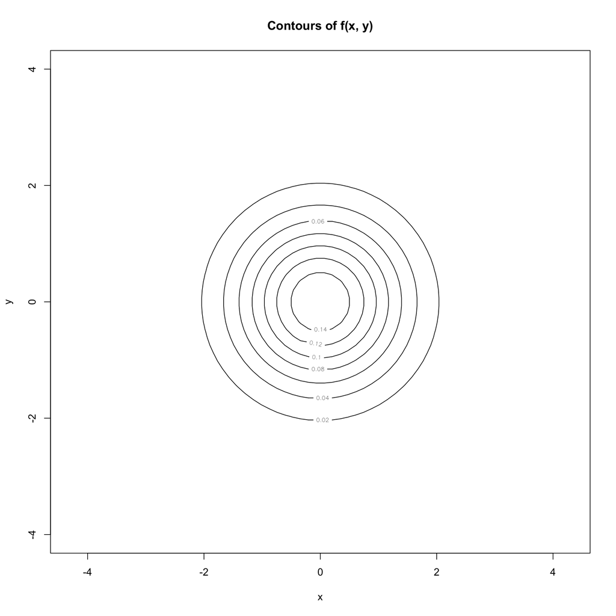

## The Bivariate Normal Distribution

[interactive chart not shown]

## The Bivariate Normal Distribution

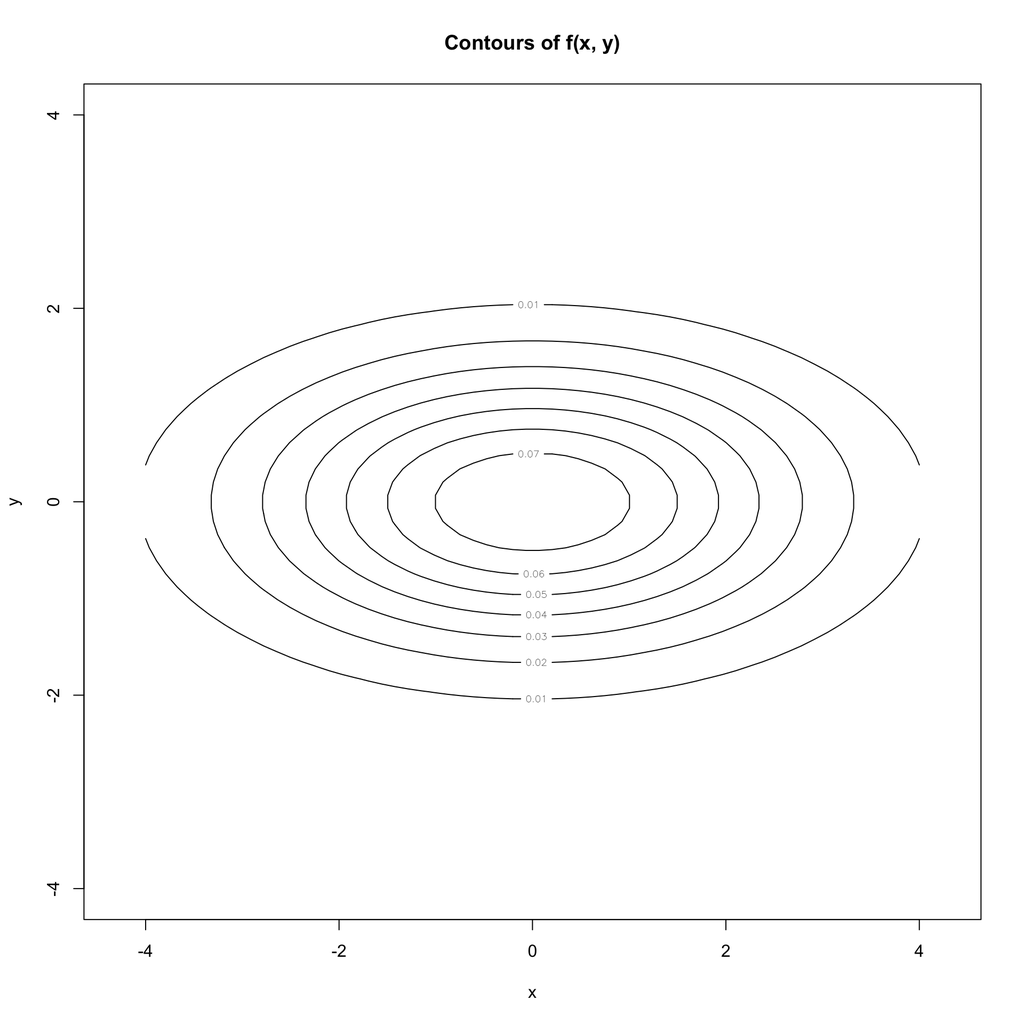

## The Bivariate Normal Distribution

[interactive chart not shown]

## The Bivariate Normal Distribution

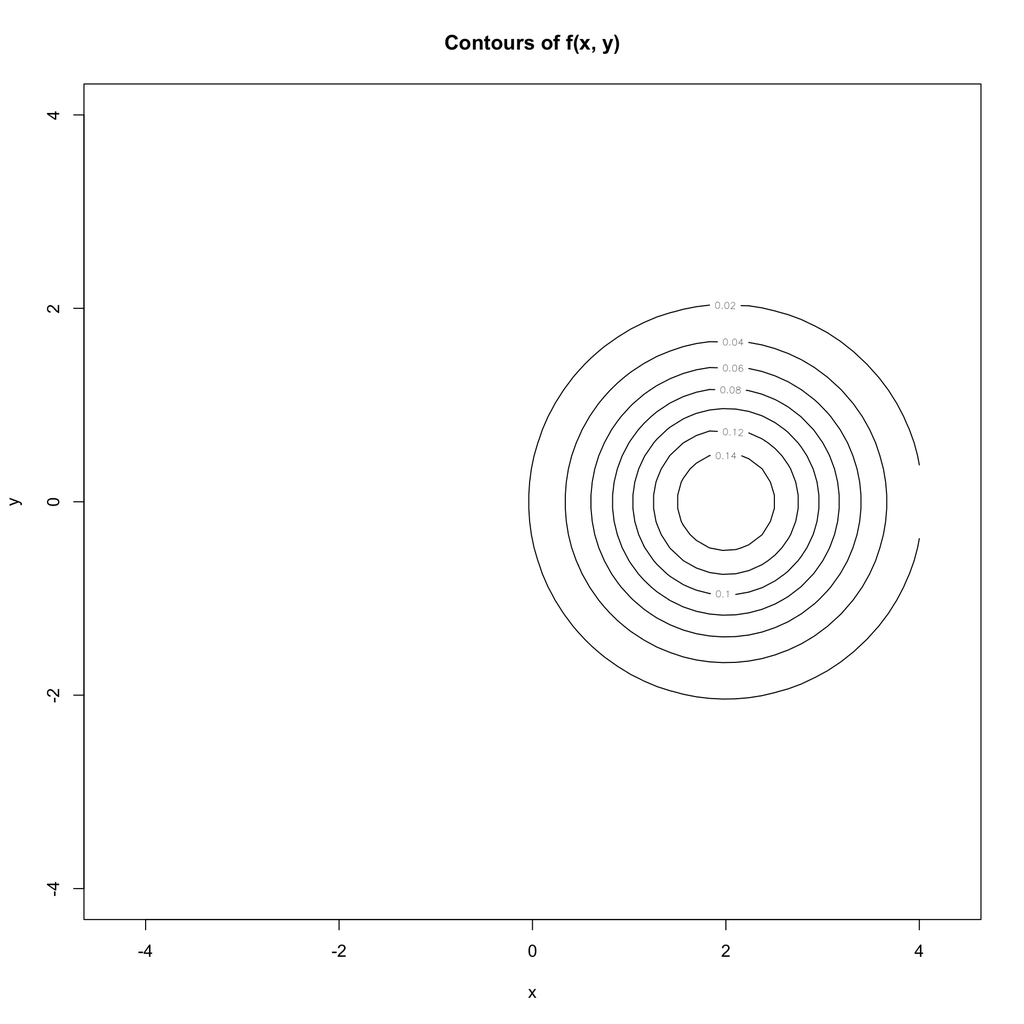

## The Bivariate Normal Distribution

But what if $X$ and $Y$ are not independent?

[interactive chart not shown]

## The Bivariate Normal Distribution

But what if $X$ and $Y$ are not independent?

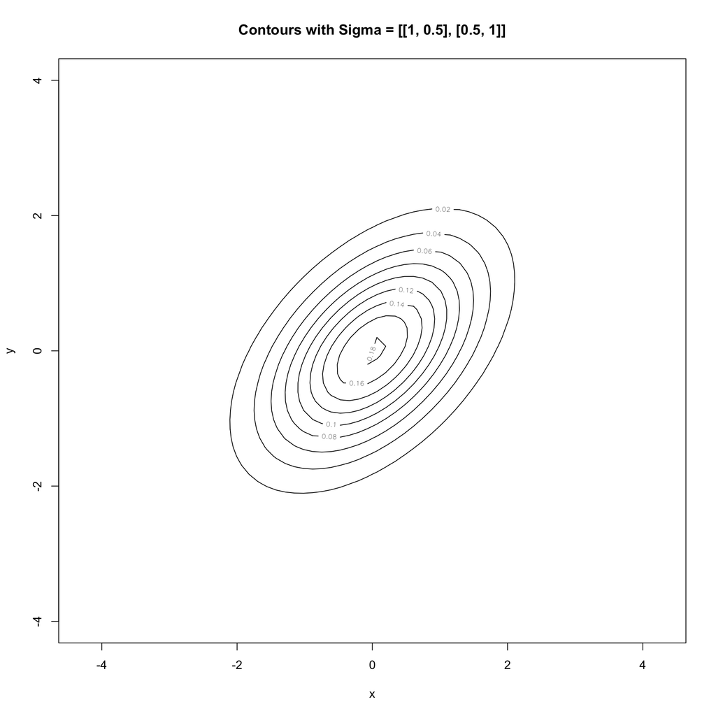

## The Bivariate Normal Distribution

Two random variables $X$ and $Y$ are said to be bivariate normal, or jointly normal, if $aX + bY$ has a Normal distribution for all $a, b \in \mathbb{R}$.

## The Standard Bivariate Normal Distribution

Two random variables $X$ and $Y$ are said to have the standard bivariate normal distribution with correlation coefficient $\rho$ if their joint PDF is given by
$$f_{XY}(x, y) = \frac{1}{2\pi \sqrt{1 - \rho^2}} \exp\left\{ -\frac{1}{2(1 - \rho^2)} \left( x^2 - 2\rho x y + y^2 \right) \right\},$$
where $\rho \in (-1, 1)$. If $\rho = 0$, then we just say $X$ and $Y$ have the standard bivariate normal distribution.

## The Standard Bivariate Normal Distribution

**Theorem:** Let $X$ and $Y$ be two bivariate normal random variables. Then there exist independent standard normal random variables $Z_1$ and $Z_2$ such that
$$\begin{aligned}
X &= \sigma_X Z_1 + \mu_X \\
Y &= \sigma_Y \Big( \rho Z_1 + \sqrt{1 - \rho^2} Z_2 \Big) + \mu_Y.
\end{aligned}$$

## The Standard Bivariate Normal Distribution

Two random variables $X$ and $Y$ are said to have the bivariate normal distribution with parameters $\mu_X$, $\sigma_X^2$, $\mu_Y$, $\sigma)Y^2$ and $\rho$ if their joint PDF is given by
$$\begin{aligned}
f_{XY}(x, y) &= \frac{1}{2\pi \sigma_X \sigma_Y \sqrt{1 - \rho^2}} \\
&\qquad \times \exp\Bigg\{ -\frac{1}{2} \Bigg[ \left( \frac{x - \mu_X}{\sigma_X} \right)^2 + \left( \frac{y - \mu_Y}{\sigma_Y} \right)^2 \\
&\qquad \qquad \qquad - 2\rho \left( \frac{(x - \mu_X)(y - \mu_Y)}{\sigma_X \sigma_Y} \right) \Bigg] \Bigg\}
\end{aligned}$$
where $\mu_X, \mu_Y \in \mathbb{R}$, $\sigma_X, \sigma_Y > 0$ and $\rho \in (-1, 1)$ are all constants.

## Conditional Expectation and Variance

**Theorem:** Suppose $X$ and $Y$ are jointly normal random variables with parameters $\mu_X$, $\sigma_X^2$, $\mu_Y$, $\sigma_Y^2$ and $\rho$. Then, given $X = x$, $Y$ is normally distributed with
$$\begin{gather*}
E[Y \mid X = x] = \mu_Y + \rho \sigma_Y \left( \frac{x - \mu_X}{\sigma_X} \right). \\
V[Y \mid X = x] = (1 - \rho^2) \sigma_Y^2.
\end{gather*}$$

**Theorem:** If $X$ and $Y$ are bivariate normal and uncorrelated, then they are independent.

## The Multivariate Normal Distribution

But we can take this further!

The random variables $X_1, X_2, \dots, X_n$ have a multivariate normal distribution if their joint PDF is given by:
$$p(x; \mu, \Sigma) = \frac{1}{(2 \pi)^{\frac{n}{2}} \lvert \Sigma \rvert^{\frac{1}{2}}} \exp\left\{ -\frac{1}{2} (\tilde{x} - \tilde{\mu})^T \Sigma^{-1} (\tilde{x} - \tilde{mu}) \right\},$$
where $\tilde{\mu} = [\mu_1, \mu_2, \dots, \mu_n]^T$ is a vector of the means, and $\Sigma$ is the covariance matrix.

## The Multivariate Normal Distribution

The marginals of a joint normal distribution is normal.

The conditional distributions of a joint normal distribution is normal.

You can think of linear regression as a joint normal distribution from the independent errors.